# Starbucks Customer Survey Evaluation - Presentation

Zhe Zhao, Yufei Sun, Anvesh kotturi

September, 2022

# Introduction

- our project is based on the Kaggle project: Starbucks Customer Survey.
- This dataset is composed of a survey questions of over 100 respondents for their buying behavior at Starbucks.
- The main idea of our project is to reproduce the original findings using the original data and collect new data with Google form then replicate the results with the new data.
- A questionnaire was made using Google form, and 39 samples were collected. We use these samples to evaluate and report on customer profiling, areas of satisfaction, and demographics to target for potential growth opportunities. The questionnaire included 20 questions, the first four questions were personal information about the participants, and the remaining questions were about our topic: *Starbucks*.
- requirements to re-run the obtained results are:

`R version 4.1.3`, `rmarkdown 2.14`, `tidyverse 1.3.2`, `tibble 3.1.8`.

# Explorations

### Gender distribution

[output not shown]

```
##   Gender  n     Ratio
## 1 Female 16 0.4102564
## 2   Male 23 0.5897436
```

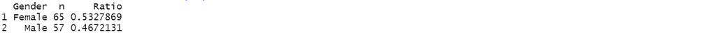

Source: Original data analysis figure.

- What we’ve gleaned is that gender is not distributed fairly, skew towards Male customers.

# Explorations

### Income distribution (Feamle ana Male)

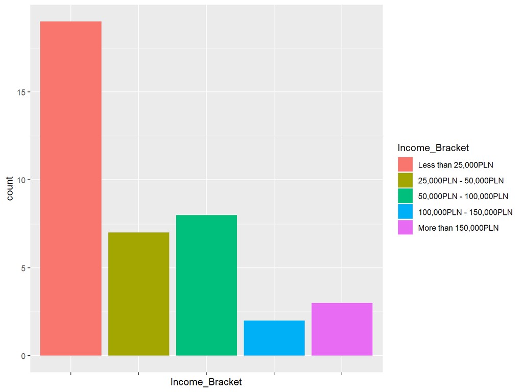

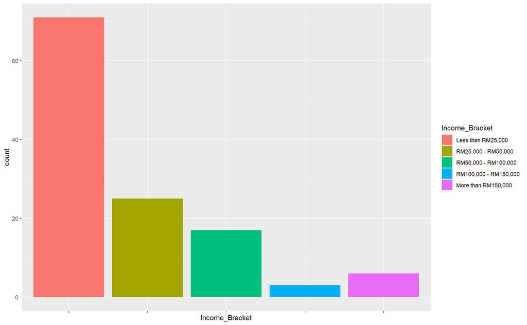

Source: Original data analysis figure.

- We can see that incomes of many participants are less than 25,000PLN. High-income participants make up a small percentage.

# Explorations

### Gender and income

- Then we combine gender and income to get a broader view.

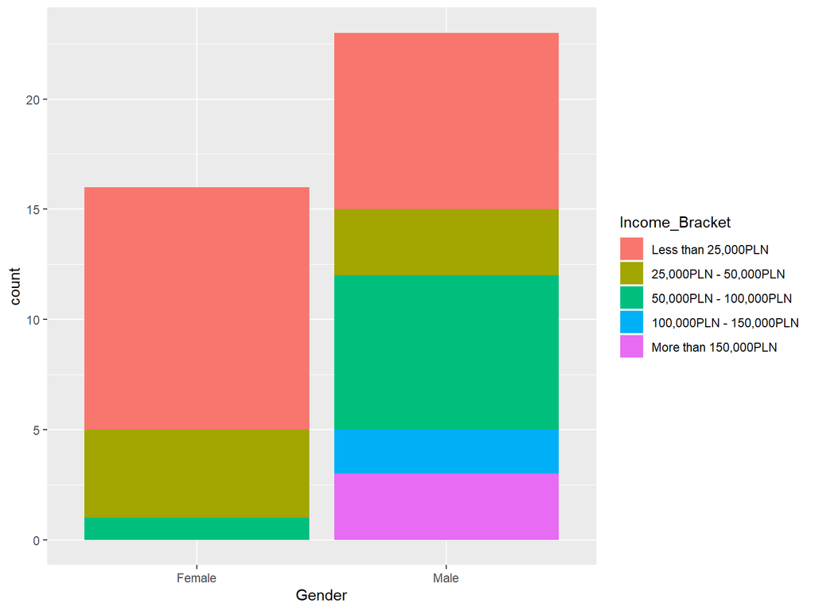

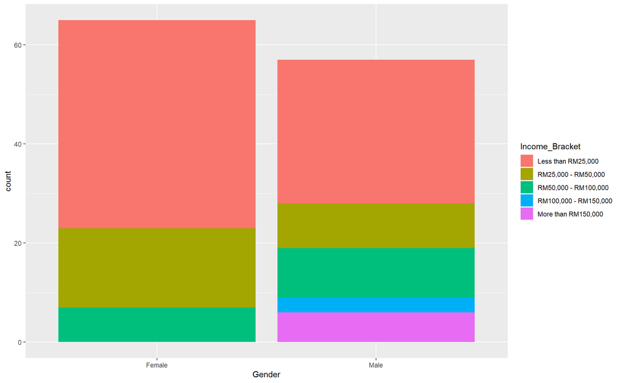

Source: Original data analysis figure.

# Explorations

### Gender and income

#### Females’ income

```
##           Income_Bracket Percentage
## 1    Less than 25,000PLN      0.688
## 2  25,000PLN - 50,000PLN      0.250
## 3 50,000PLN - 100,000PLN      0.062
```

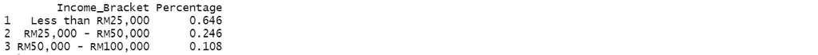

Source: Original data analysis figure.

# Explorations

### Gender and income

#### Males’ income

```
##            Income_Bracket Percentage
## 1     Less than 25,000PLN      0.348
## 2   25,000PLN - 50,000PLN      0.130
## 3  50,000PLN - 100,000PLN      0.304
## 4 100,000PLN - 150,000PLN      0.087
## 5    More than 150,000PLN      0.130
```

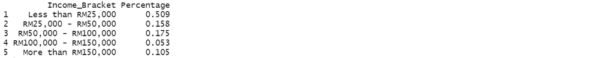

Source: Original data analysis figure.

# Explorations

### Gender and income

#### Combine income and gender (1/2)

- Then we combine income and gender.

```
##              IncomeBracket    Gender Percent
## 1  100,000PLN - 150,000PLN Percent_M     8.7
## 2    25,000PLN - 50,000PLN Percent_M    13.0
## 3   50,000PLN - 100,000PLN Percent_M    30.4
## 4      Less than 25,000PLN Percent_M    34.8
## 5     More than 150,000PLN Percent_M    13.0
## 6  100,000PLN - 150,000PLN Percent_F     0.0
## 7    25,000PLN - 50,000PLN Percent_F    25.0
## 8   50,000PLN - 100,000PLN Percent_F     6.2
## 9      Less than 25,000PLN Percent_F    68.8
## 10    More than 150,000PLN Percent_F     0.0
```

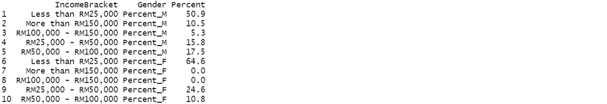

Source: Original data analysis figure.

# Explorations

### Gender and income

#### Combine income and gender (2/2)

- We can show them in a barplot.

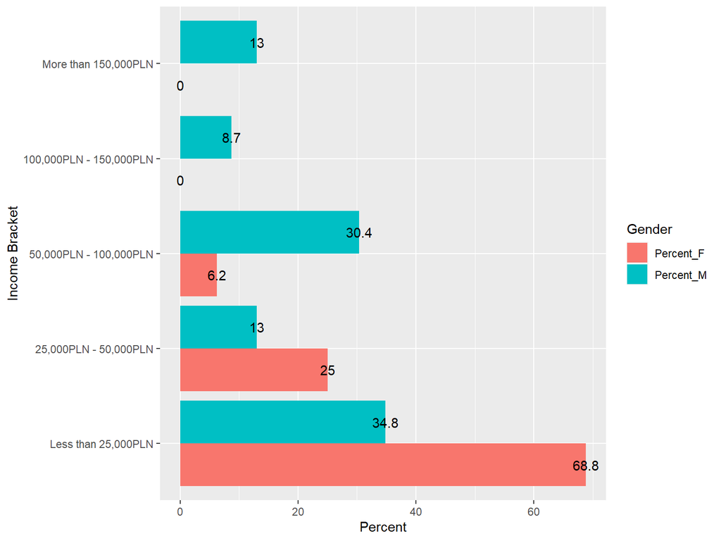

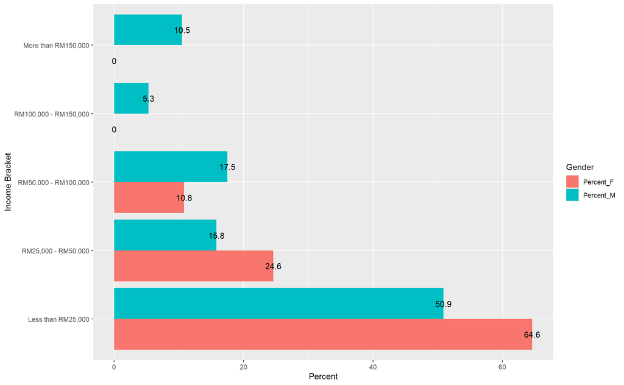

Source: Original data analysis figure.

- We can see from this barplot, over 40% males occupy the higher income brackets (any more that 50,000PLN), most of females occupy the lower income brackets.
- So we can assume that when the gender distribution is fairly even female-identifying customers lean more towards the lower income brackets, while more males occupy the higher income brackets.

# Explorations

### 7 rated questions and Gender (1/3)

- Here are 7 more survey questions to score, and we’ll analyze them next with gender.

```
##   Female     Male
## 3.491071 3.546584
```

[figure not shown]

Source: Original data analysis figure.

- Males are slightly more favorable overall towards the brand (3.55), but not much more than women (3.49).
- In general, the feelings are leaning on the ‘satisfied’ side of ‘neutral’.

# Explorations

### 7 rated questions and Gender (2/3)

- We can create a collated dataframe of all the surveyed, ranked variables by gender.

```
##   Gender  AmbRat Sales_Promo_Rating Quality_Rating Price_Rating WiFi_Rating
## 1 Female 3.68750           3.812500       3.625000     2.937500    3.375000
## 2   Male 3.73913           3.434783       3.956522     3.086957    3.391304
##   Service_Rating Meetup_Rating
## 1        3.75000      3.250000
## 2        3.73913      3.478261
```

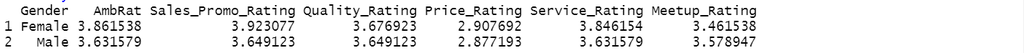

Source: Original data analysis figure.

# Explorations

### 7 rated questions and Gender (3/3)

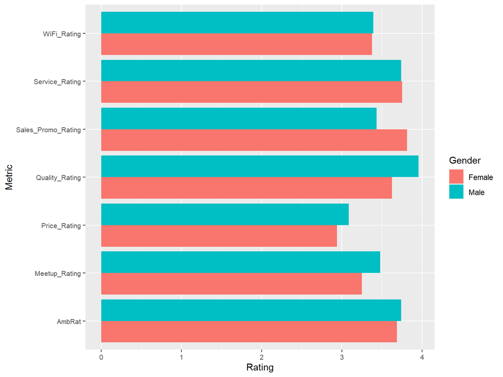

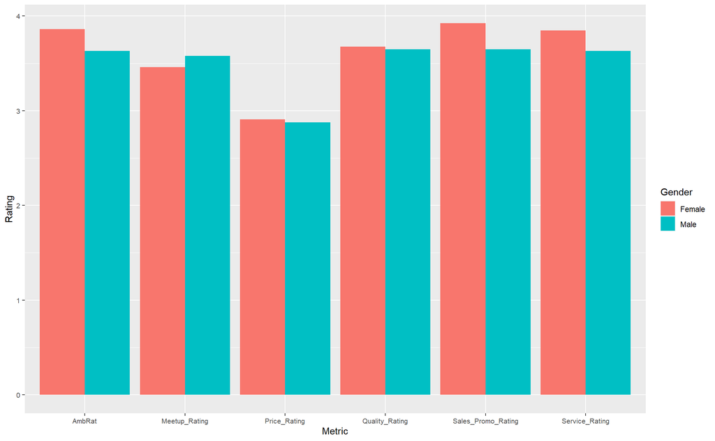

Source: Original data analysis figure.

- The results are not very different by gender. Men and women are fairly similar in their ratings, but there are some difference in a few areas: Women are more satisfied with *Sales/Promotions*, while men are more satisfied with *the use of Starbucks for meetings/get-togethers* and *quality of coffee*.

# Explorations

### Spending and Gender (1/2)

- Check which gender spends more per trip: “Spending”.

```
##   Gender         Spending  n
## 1 Female            0 PLN  3
## 2 Female  20 PLN - 40 PLN  4
## 3 Female Less than 20 PLN  9
## 4   Male  20 PLN - 40 PLN 13
## 5   Male Less than 20 PLN  8
## 6   Male More than 40 PLN  2
```

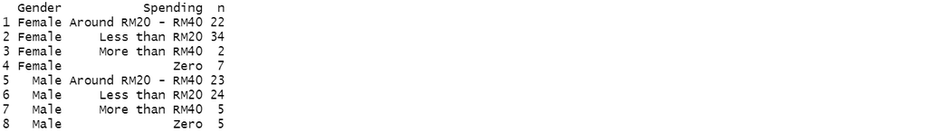

Source: Original data analysis figure.

# Explorations

### Spending and Gender (2/2)

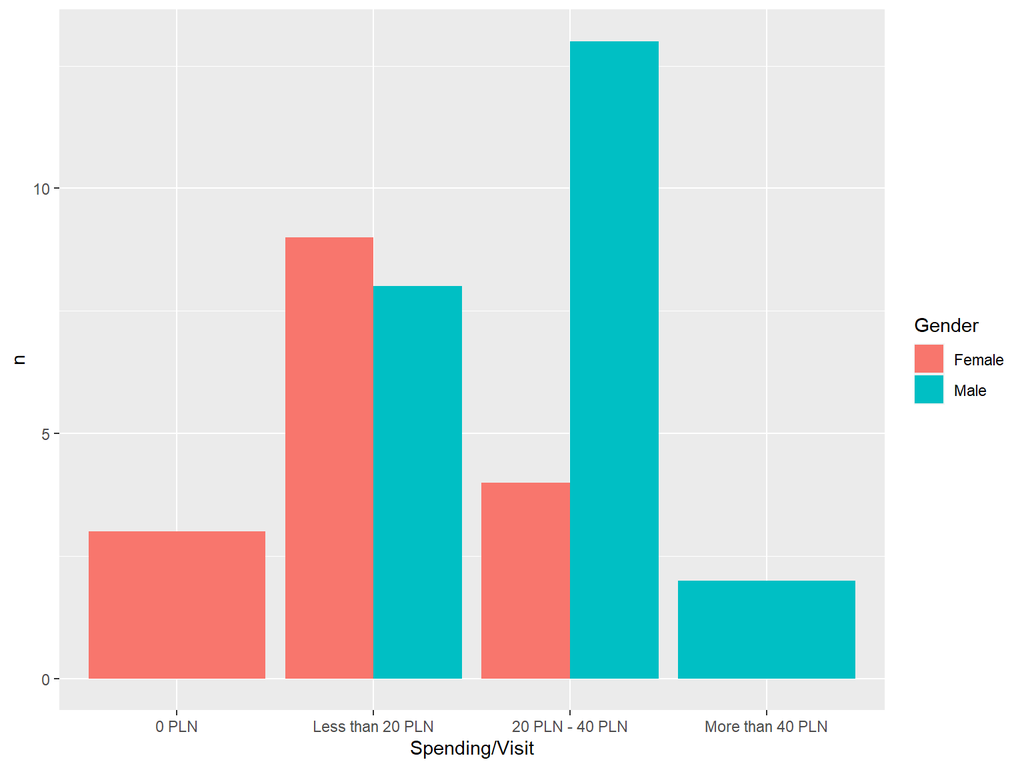

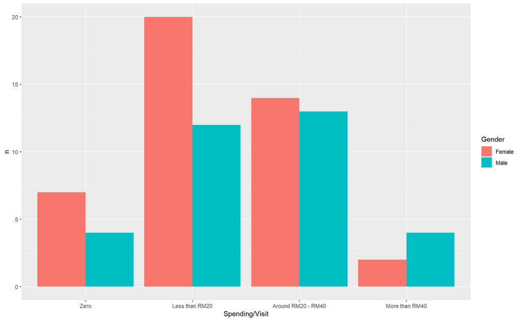

Source: Original data analysis figure.

# Explorations

### Membership and Gender

- Next, we analyze whether membership is related to Gender.

```
##   Gender Membership  n
## 1 Female         No  9
## 2 Female        Yes  7
## 3   Male         No 10
## 4   Male        Yes 13
```

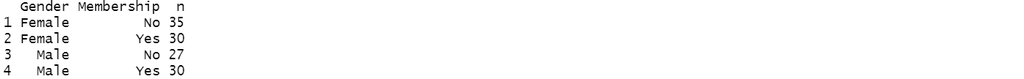

Source: Original data analysis figure.

- Men are more likely to have a membership than women.

# Explorations

### Willingness to continue buying and Gender

- Now that we know that men and women rate Starbucks similarly but not identically, we will analyze whether there is a significant difference in the willingness to continue to buy between different genders.

```
##   Gender Cont_Buying  n
## 1 Female          No  3
## 2 Female         Yes 13
## 3   Male          No  2
## 4   Male         Yes 21
```

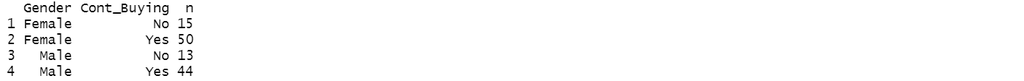

Source: Original data analysis figure.

- About 87% participants say they’ll keep going to Starbucks. So most of men and women are willing to continue to buy Starbucks, regardless of variable gender.

# Explorations

### Membership and Spending

- The difference in spending between members and non-members

```
##   Membership         Spending  n
## 1         No            0 PLN  3
## 2         No  20 PLN - 40 PLN  8
## 3         No Less than 20 PLN  7
## 4         No More than 40 PLN  1
## 5        Yes  20 PLN - 40 PLN  9
## 6        Yes Less than 20 PLN 10
## 7        Yes More than 40 PLN  1
```

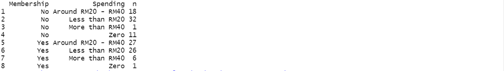

Source: Original data analysis figure.

- Members and non-Members are spending about the same.

# Explorations

### Willing to continue buying and Membership

- We know that members’ willingness to continue to buy is unquestionable, but we do not know the willingness of non-members to continue to buy, so we analyze the willingness of members and non-members to continue to buy.

```
##   Membership Cont_Buying  n
## 1         No          No  4
## 2         No         Yes 15
## 3        Yes          No  1
## 4        Yes         Yes 19
```

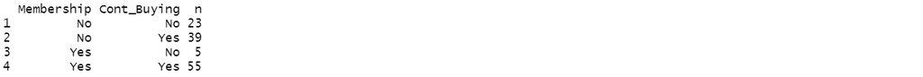

Source: Original data analysis figure.

# Summary